# Encontros relâmpagos - match

```r
library(tidyverse)
library(here)
library(GGally)
library(broom)
library(pscl)
theme_set(theme_bw())
```

Para esse checkpoint, utilizaremos novamente os dados de encontros relâmpagos e analisaremos o fator se após esse encontro há interesse em encontrar com aquela pessoa novamente.

```r
encontro_match = read_csv(here("data/speed-dating2.csv"))
```

```r
encontro_match <- encontro_match %>%
  mutate(dec = case_when(dec == 'no' ~ 0,
                         dec == 'yes' ~ 1))
```

Para isso, iremos utilizar os conceitos de regressão logística para responder as perguntas abaixo:

### Dentre os fatores que você acha que podem ter efeito no match, quais fatores têm efeito significativo na chance de p1 decidir se encontrar novamente com p2? E como é esse efeito (positivo/negativo)?

Primeiramente, selecionei algumas variáveis para verificar sua correlação com a variável dec e sendo assim, posteriormente escolher as com correlação mais forte para utilizá-las no modelo.

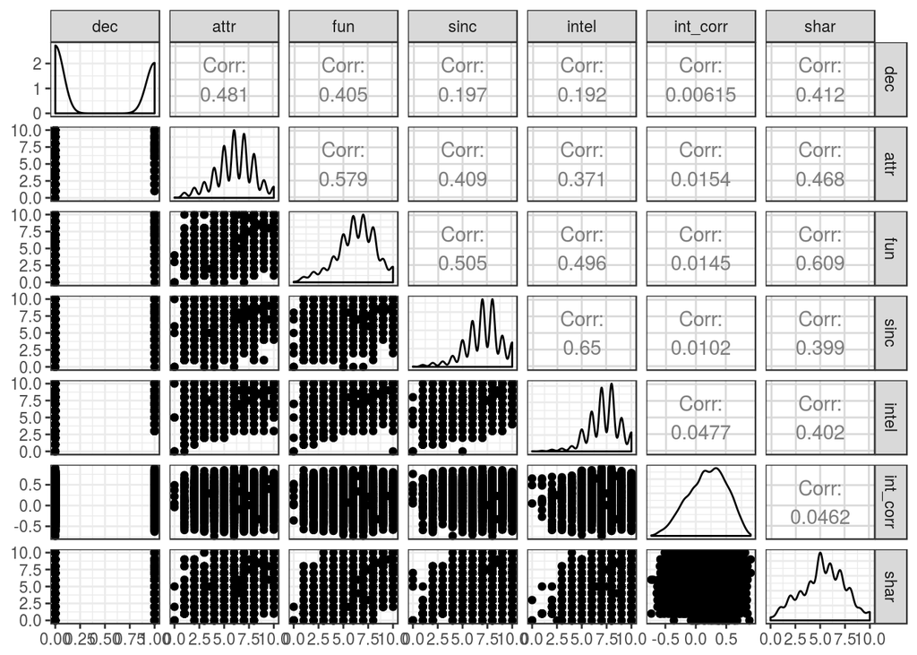

```r
encontro_match %>%
  select(dec,
         attr,
         fun,
         sinc,
         intel,
         int_corr,
         shar) %>%
  na.omit(.) %>%
  ggpairs(progress=FALSE)
```

Como podemos observar acima, as variáveis attr, fun e shar possuem uma correlação forte com a variável dec. Então, vamos utilizá-las para nosso modelo.

```r
modelo_match <- glm(dec ~ attr + fun + shar,
                    data = encontro_match,
                    family = 'binomial')
```

```r
tidy(modelo_match, conf.int = TRUE, exponentiate = TRUE)
```

| term | estimate | std.error | statistic | p.value | conf.low | conf.high |
| --- | --- | --- | --- | --- | --- | --- |
| (Intercept) | 0.002156708 | 0.20935977 | -29.323554 | 5.195633e-189 | 0.00142128 | 0.00322969 |
| attr | 1.706428673 | 0.02736422 | 19.529248 | 6.194492e-85 | 1.61820864 | 1.80148648 |
| fun | 1.165521115 | 0.02687045 | 5.700251 | 1.196312e-08 | 1.10583350 | 1.22870173 |
| shar | 1.315936648 | 0.02267309 | 12.109012 | 9.462684e-34 | 1.25904670 | 1.37610562 |

Para as variáveis acima, podemos observar que todas influenciam positivamente para marcar um segundo encontro. No entanto, fatores como atraência tem uma influência forte para um segundo encontro. Para os valores do p-valor, mostra o quão significante são as variáveis para o dec Logo, podemos ver que os valores nesta coluna estão bem próximos de zero, então podemos dizer que essas variáveis representam bem o modelo.

```r
pR2(modelo_match)
```

```
##           llh       llhNull            G2      McFadden          r2ML
## -2165.3107168 -3338.8632511  2347.1050687     0.3514827     0.4243526
##          r2CU
##     0.5356564
```

Na regressão logística não podemos utilizar o R-quadrado, então podemos usar um pseudo R-quadrado, com a medida de McFadden para verificar se nosso modelo é bom. Então, a partir da observação acima, temos um valor muito bom para nosso pseudo R-quadrado, cerca de 35,14%. Dessa maneira, podemos afirmar que as variáveis que escolhemos formam um bom modelo.

### Que fatores nos dados têm mais efeito na chance de um participante querer se encontrar novamente com outro?

Assim como mostrado acima, podemos observar que o fator da attr(atraência) tem grande influência sobre o modelo. Dessa forma, podemos dizer essa variável é um dos fatores importantes para um participante querer encontrar novamente um dos participantes do date.